# Multi-variate Linear Regression Model

### Evaluate model assumptions

**Residuals vs Fitted plot:**

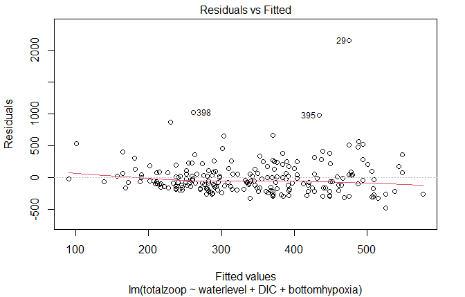

1. *Residuals vs Fitted plot* checks **linearity assumption**. If the red line, represents residual distribution, in the plot align with the dashed black line (horizontal at zero), it indicates linear relationship exists in the model.
   - we can also test linear relationship by simply do a scatter plot between each predictor variable and the response variable, using `plot()`. For example, `plot(multi_data$totalzoop~multi_data$DIC)`, and we can add a linear regression line by using `abline()` and a single linear model between these two variables using `lm()`.

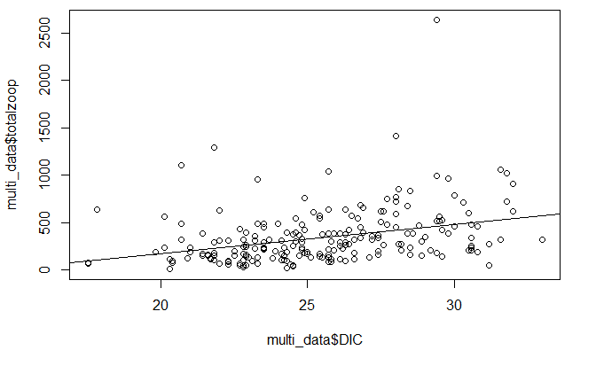

```
  The R squared of the linear regression line can be extracted and evaluate whether the relationship is linear: `summary(lm(totalzoop~DIC,data=multi_data))$r.squared`.
```

**Normal Q-Q plot:**

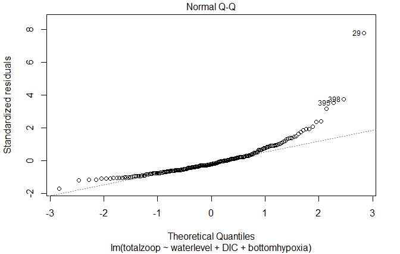

2. *Normal Q-Q plot* checks the **normality of residuals** assumption. If the standardized residuals follow the straight dashed line, then the assumption is fulfilled.
   - Another simpler way to visualize and check it is to plot histogram using (`hist()`) model residuals.

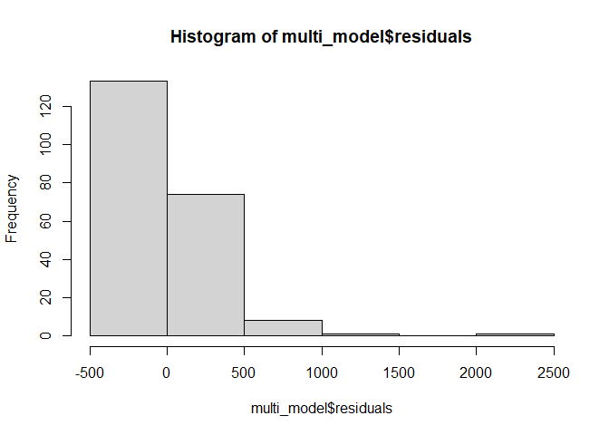

**Scale-Location plot:**

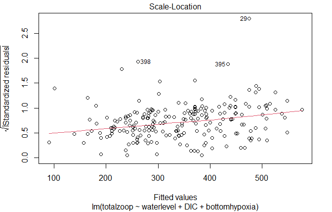

3. *Scale-Location plot* is used to check the **homoscedasticity**. If the residuals have equal variance, the standardized will spread randomly with the red line approximate horizontal line.
   - If heteroscedasticity is found, we can try to eliminate it by doing non-linear data transformation or adding quadratic terms.

**Residuals vs Leverage plot:**

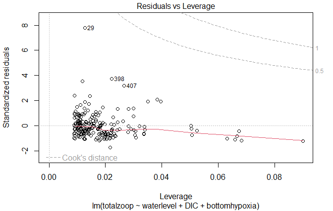

- *The Residuals vs Leverage plot is not used to check any of the model assumptions. However, it is still important and worth checking as it is used to identify extreme values that can cause a huge influence to our analysis of the model output based on Cook’s distance. Extreme values can be identified as any of the values are outside of the dashed lines.*
4. The above diagnosis plots check three out of the total four assumptions of this model, the last one, **Multicollinearity**, can be checked by the following several ways depending on the data characteristics:
   - If we only have continuous variables in our dataset, we can check this using correlation matrix through `cor()` or/and `corrplot()`, or variance inflation factor using `vif()` from the *car* package, or`vifcor()` and `vifstep()` from the *usdm* package.
   - If we have both continuous and categorical variables in our dataset, we need to transfer our categorical variables into dummy variables and viewing them as a single entity. We have already done that in [2. Data preparation]. The `vif()` function will automatically detect our categorical variables and compute us the generalized vifs.

   ```r
   vif(multi_model)
   ```

   ```
   ##    waterlevel           DIC bottomhypoxia
   ##      1.577214      1.780762      1.165722
   ```

   - Our variables look good. If multicollinearity is found (vif > 5 is indicating problematic amount of multicollinearity), we can try to remove it by identify and remove the predictor variable that is causing troubles.

### Output interpretation

To access model output, the easiest way is to call the `summary()` method just like the single variate linear regression model:

```r
summary(multi_model)
```

```
##
## Call:
## lm(formula = totalzoop ~ waterlevel + DIC + bottomhypoxia, data = multi_data)
##
## Residuals:
##     Min      1Q  Median      3Q     Max
## -479.49 -169.14  -65.33   79.96 2158.84
##
## Coefficients:
##                 Estimate Std. Error t value Pr(>|t|)
## (Intercept)    -1053.213   6693.092  -0.157 0.875112
## waterlevel         9.476     90.954   0.104 0.917119
## DIC               27.790      7.884   3.525 0.000519 ***
## bottomhypoxia1   -48.853     40.968  -1.192 0.234401
## ---
## Signif. codes:  0 '***' 0.001 '**' 0.01 '*' 0.05 '.' 0.1 ' ' 1
##
## Residual standard error: 278.8 on 213 degrees of freedom
## Multiple R-squared:  0.119,  Adjusted R-squared:  0.1066
## F-statistic: 9.595 on 3 and 213 DF,  p-value: 5.717e-06
```

However, unlike the single variate model, you can compare the coefficients and significance of multiple predictors and decide on whether you want to exclude some of the variables in your final model. In this case, DIC seems to be the most significant variable and we might be able to get a similarly accurate model from this single predictor

## What could go wrong?

- Check carefully whether the values in your data set are in their correct data types, especially for the categorical variables if you have any.
- Be careful with the *comma ,* and *tilde ~* symbols when you are dealing with functions in R. They represent opposite positions of the independent and dependent variables.
- Always check the model assumptions to see if linear regression model is indeed the appropriate model to use.

## References and Resources

Other resources on introductions to multivariate linear regression model in R:  
https://www.datacamp.com/tutorial/multiple-linear-regression-r-tutorial  
https://bookdown.org/jimr1603/Intermediate_R_-_R_for_Survey_Analysis/regression-model.html#multiple-linear-regression  
https://library.virginia.edu/data/articles/getting-started-with-multivariate-multiple-regression  
https://rpubs.com/bensonsyd/385183

If you would like to have prettier plots for presentation purposes, check the *ggplot2* package: https://ggplot2.tidyverse.org/